# Analysis on the Relationship between Prison Incarcerations, Admissions, Releases and Race

By Felix Gu

## Introduction

In the landscape of criminal justice, few issues are as deeply intertwined and contentious as those surrounding race and prison incarcerations. The United States has the highest incarceration rate of any country in the world and the intersection of race and incarceration presents a complex tapestry of social, economic, and systemic factors that have profound implications for individuals, communities, and society as a whole.

Incarcerations reflect broader societal issues such as inequality, discrimination, and systemic biases within the criminal justice system. Addressing disparities in incarcerations is essential for promoting social justice and ensuring equal treatment under the law for all individuals, regardless of race, ethnicity, or socioeconomic status. Incarcerations impact not only individuals but also families, communities, and society as a whole. High rates of incarceration can destabilize communities, disrupt families, and perpetuate cycles of poverty and crime. Addressing mass incarceration is essential for promoting community well-being and fostering safer, healthier neighborhoods.

This project examines the US incarceration rate, along with the admission and release rates of documented races within the state of Arizona from 2015-2022. This smaller scale view is not a reflection of the issue within America, it's not even a reflection of the issue within the state of Arizona. But a smaller data set is easier to examine for the purposes of a tutorial. Here, we will walk through the steps of the Data Science Lifecycle, as well as the code and analysis accompanying it.

## Imports

For this project, we will be using Python and importing libraries to use later. These are the libraries needed:

```python
import numpy as np
import pandas as pd
import matplotlib.pyplot as plt
import statsmodels.api
import statsmodels.formula.api as sm
import statsmodels.formula.api as smf
from sklearn.model_selection import train_test_split
from sklearn.linear_model import LinearRegression
from sklearn.preprocessing import OneHotEncoder
import seaborn as sns
```

## Data Collection

The data we will be using is from a collaboration between researchers at the Institute on Policing, Incarceration, and Public Safety at Harvard University, Yale University, the Santa Fe Institute, MIT, and Northeastern University, used in the paper: "COVID-19 amplified racial disparities in the US criminal legal system" by Brennan Klein, C. Brandon Ogbunugafor, Benjamin J. Schafer, Zarana Bhadricha, Preeti Kori, Jim Sheldon, Nitish Kaza, Arush Sharma, Emily A. Wang, Tina Eliassi-Rad, Samuel V. Scarpino & Elizabeth Hinton.

We will be accessing the data they used through their github: https://github.com/jkbren/incarcerated-populations-data/tree/main

Download the data and the two csv files, "admissions_releases_states.csv" and "populations_states.csv" which contain the admissions and releases by race in states, and the total incarceration population and the population of races within the states respectively.

Because these are csv files, we can load them directly into pandas. We'll start with "admissions_releases_states.csv" using the code below:

```python
url = 'admissions_releases_states.csv'

admission_release_df = pd.read_csv(url)
display(admission_release_df)
```

|  | date | admissions_total | admissions_white | admissions_black | admissions_hispanic | admissions_amerind | admissions_asian | admissions_other | releases_total | releases_white | releases_black | releases_hispanic | releases_amerind | releases_asian | releases_other | state |
| --- | --- | --- | --- | --- | --- | --- | --- | --- | --- | --- | --- | --- | --- | --- | --- | --- |
| 0 | 2015-02-01 | 1583 | 600 | 193 | 633.0 | 130.0 | 6.0 | 21.0 | 1649 | 653 | 194 | 688.0 | 85.0 | 7.0 | 22.0 | Arizona |
| 1 | 2015-03-01 | 1580 | 615 | 189 | 640.0 | 114.0 | 3.0 | 19.0 | 1559 | 644 | 169 | 610.0 | 111.0 | 6.0 | 19.0 | Arizona |
| 2 | 2015-04-01 | 1779 | 706 | 235 | 701.0 | 115.0 | 4.0 | 18.0 | 1693 | 703 | 206 | 657.0 | 93.0 | 5.0 | 29.0 | Arizona |
| 3 | 2015-05-01 | 1821 | 730 | 260 | 669.0 | 125.0 | 8.0 | 29.0 | 1659 | 685 | 193 | 616.0 | 136.0 | 3.0 | 26.0 | Arizona |
| 4 | 2015-06-01 | 1689 | 704 | 215 | 618.0 | 129.0 | 0.0 | 23.0 | 1570 | 651 | 174 | 603.0 | 111.0 | 7.0 | 24.0 | Arizona |
| ... | ... | ... | ... | ... | ... | ... | ... | ... | ... | ... | ... | ... | ... | ... | ... | ... |
| 1909 | 2022-03-01 | 3475 | 812 | 746 | 1753.0 | 0.0 | 0.0 | 164.0 | 3018 | 669 | 785 | 1395.0 | 0.0 | 0.0 | 169.0 | California |
| 1910 | 2022-04-01 | 3126 | 770 | 701 | 1490.0 | 0.0 | 0.0 | 165.0 | 2585 | 571 | 631 | 1239.0 | 0.0 | 0.0 | 144.0 | California |
| 1911 | 2022-05-01 | 3221 | 851 | 699 | 1479.0 | 0.0 | 0.0 | 192.0 | 2673 | 647 | 633 | 1252.0 | 0.0 | 0.0 | 141.0 | California |
| 1912 | 2022-06-01 | 2624 | 611 | 576 | 1290.0 | 0.0 | 0.0 | 147.0 | 2590 | 646 | 560 | 1231.0 | 0.0 | 0.0 | 153.0 | California |
| 1913 | 2022-07-01 | 2192 | 604 | 479 | 981.0 | 0.0 | 0.0 | 128.0 | 2626 | 671 | 593 | 1215.0 | 0.0 | 0.0 | 147.0 | California |

1914 rows × 16 columns

However, this dataframe contains data from a lot of different states. Because we are focused only on the state of Arizona, we want to isolate that data down.

```python
ad_re = admission_release_df[:-1822]
display(ad_re)
```

|  | date | admissions_total | admissions_white | admissions_black | admissions_hispanic | admissions_amerind | admissions_asian | admissions_other | releases_total | releases_white | releases_black | releases_hispanic | releases_amerind | releases_asian | releases_other | state |
| --- | --- | --- | --- | --- | --- | --- | --- | --- | --- | --- | --- | --- | --- | --- | --- | --- |
| 0 | 2015-02-01 | 1583 | 600 | 193 | 633.0 | 130.0 | 6.0 | 21.0 | 1649 | 653 | 194 | 688.0 | 85.0 | 7.0 | 22.0 | Arizona |
| 1 | 2015-03-01 | 1580 | 615 | 189 | 640.0 | 114.0 | 3.0 | 19.0 | 1559 | 644 | 169 | 610.0 | 111.0 | 6.0 | 19.0 | Arizona |
| 2 | 2015-04-01 | 1779 | 706 | 235 | 701.0 | 115.0 | 4.0 | 18.0 | 1693 | 703 | 206 | 657.0 | 93.0 | 5.0 | 29.0 | Arizona |
| 3 | 2015-05-01 | 1821 | 730 | 260 | 669.0 | 125.0 | 8.0 | 29.0 | 1659 | 685 | 193 | 616.0 | 136.0 | 3.0 | 26.0 | Arizona |
| 4 | 2015-06-01 | 1689 | 704 | 215 | 618.0 | 129.0 | 0.0 | 23.0 | 1570 | 651 | 174 | 603.0 | 111.0 | 7.0 | 24.0 | Arizona |
| ... | ... | ... | ... | ... | ... | ... | ... | ... | ... | ... | ... | ... | ... | ... | ... | ... |
| 87 | 2022-05-01 | 1172 | 427 | 153 | 485.0 | 79.0 | 5.0 | 23.0 | 1124 | 415 | 148 | 425.0 | 93.0 | 3.0 | 40.0 | Arizona |
| 88 | 2022-06-01 | 1145 | 424 | 171 | 429.0 | 96.0 | 6.0 | 19.0 | 1248 | 422 | 191 | 480.0 | 115.0 | 7.0 | 33.0 | Arizona |
| 89 | 2022-07-01 | 1027 | 369 | 135 | 406.0 | 89.0 | 4.0 | 24.0 | 1187 | 430 | 161 | 450.0 | 103.0 | 1.0 | 42.0 | Arizona |
| 90 | 2022-08-01 | 1076 | 377 | 172 | 415.0 | 90.0 | 8.0 | 14.0 | 1121 | 414 | 152 | 431.0 | 99.0 | 5.0 | 20.0 | Arizona |
| 91 | 2022-09-01 | 1275 | 459 | 191 | 503.0 | 98.0 | 2.0 | 22.0 | 1214 | 473 | 146 | 471.0 | 90.0 | 8.0 | 26.0 | Arizona |

92 rows × 16 columns

Now we will load "population_states.csv" into pandas.

```python
url2 = 'populations_states.csv'
population_df = pd.read_csv(url2)
display(population_df)
```

|  | date | data_or_inferred | incarcerated_total | incarcerated_white | incarcerated_black | incarcerated_hispanic | incarcerated_amerind | incarcerated_asian | incarcerated_other | incarcerated_unknown | incarcerated_nonwhite | state | url |
| --- | --- | --- | --- | --- | --- | --- | --- | --- | --- | --- | --- | --- | --- |
| 0 | 1/1/2000 | raw data | 25213.0 | 8753 | 16382.0 | NaN | NaN | NaN | 78.0 | NaN | 16460.0 | Alabama | http://www.doc.state.al.us/StatReports |
| 1 | 2/1/2000 | raw data | 25213.0 | 8753 | 16382.0 | NaN | NaN | NaN | 78.0 | NaN | 16460.0 | Alabama | http://www.doc.state.al.us/StatReports |
| 2 | 3/1/2000 | raw data | 25161.0 | 8723 | 16361.0 | NaN | NaN | NaN | 77.0 | NaN | 16438.0 | Alabama | http://www.doc.state.al.us/StatReports |
| 3 | 4/1/2000 | raw data | 25200.0 | 8738 | 16380.0 | NaN | NaN | NaN | 82.0 | NaN | 16462.0 | Alabama | http://www.doc.state.al.us/StatReports |
| 4 | 5/1/2000 | raw data | 25226.0 | 8788 | 16358.0 | NaN | NaN | NaN | 80.0 | NaN | 16438.0 | Alabama | http://www.doc.state.al.us/StatReports |
| ... | ... | ... | ... | ... | ... | ... | ... | ... | ... | ... | ... | ... | ... |
| 9580 | 5/1/2022 | raw data | 156704.0 | 90396 | 60041.0 | NaN | 3998.0 | 2269.0 | NaN | NaN | 66308.0 | Federal | https://www.bop.gov/about/statistics/statistic... |
| 9581 | 6/1/2022 | raw data | 157426.0 | 90785 | 60370.0 | NaN | 3997.0 | 2274.0 | NaN | NaN | 66641.0 | Federal | https://www.bop.gov/about/statistics/statistic... |
| 9582 | 7/1/2022 | raw data | 157435.0 | 90792 | 60386.0 | NaN | 3995.0 | 2262.0 | NaN | NaN | 66643.0 | Federal | https://www.bop.gov/about/statistics/statistic... |
| 9583 | 8/1/2022 | raw data | 157565.0 | 90837 | 60470.0 | NaN | 4015.0 | 2243.0 | NaN | NaN | 66728.0 | Federal | https://www.bop.gov/about/statistics/statistic... |
| 9584 | 9/1/2022 | raw data | 158041.0 | 91122 | 60652.0 | NaN | 4023.0 | 2244.0 | NaN | NaN | 66919.0 | Federal | https://www.bop.gov/about/statistics/statistic... |

9585 rows × 13 columns

Because this dataset also contains data from multiple states, we also want to isolate the data to strictly Arizona

```python
pop_df = population_df.iloc[400:553]
display(ariz_inc)
```

[output not shown]

In this dataset, we have data from years before the other dataset. To match the ad_re dataframe, we isolate the dates from 2015-2022.

```python
pop_df = pop_df.iloc[60:]
display(pop_df)
```

|  | date | data_or_inferred | incarcerated_total | incarcerated_white | incarcerated_black | incarcerated_hispanic | incarcerated_amerind | incarcerated_asian | incarcerated_other | incarcerated_unknown | incarcerated_nonwhite | state | url |
| --- | --- | --- | --- | --- | --- | --- | --- | --- | --- | --- | --- | --- | --- |
| 460 | 1/1/2015 | raw data | 42136.0 | 16678 | 5601.0 | 17057.0 | 2147.0 | NaN | 653.0 | NaN | 25458.0 | Arizona | https://corrections.az.gov/reports-documents/r... |
| 461 | 2/1/2015 | raw data | 42070.0 | 16651 | 5599.0 | 16841.0 | 2188.0 | NaN | 791.0 | NaN | 25419.0 | Arizona | https://corrections.az.gov/reports-documents/r... |
| 462 | 3/1/2015 | raw data | 42091.0 | 16600 | 5617.0 | 16832.0 | 2229.0 | NaN | 813.0 | NaN | 25491.0 | Arizona | https://corrections.az.gov/reports-documents/r... |
| 463 | 4/1/2015 | raw data | 42177.0 | 16600 | 5645.0 | 16853.0 | 2232.0 | NaN | 847.0 | NaN | 25577.0 | Arizona | https://corrections.az.gov/reports-documents/r... |
| 464 | 5/1/2015 | raw data | 42339.0 | 16628 | 5683.0 | 16902.0 | 2239.0 | NaN | 887.0 | NaN | 25711.0 | Arizona | https://corrections.az.gov/reports-documents/r... |
| ... | ... | ... | ... | ... | ... | ... | ... | ... | ... | ... | ... | ... | ... |
| 548 | 5/1/2022 | raw data | 33634.0 | 12805 | 5025.0 | 13158.0 | 1848.0 | NaN | 798.0 | NaN | 20829.0 | Arizona | https://corrections.az.gov/reports-documents/r... |
| 549 | 6/1/2022 | raw data | 33531.0 | 12811 | 5005.0 | 13164.0 | 1846.0 | NaN | 705.0 | NaN | 20720.0 | Arizona | https://corrections.az.gov/reports-documents/r... |
| 550 | 7/1/2022 | raw data | 33371.0 | 12761 | 4985.0 | 13112.0 | 1839.0 | NaN | 674.0 | NaN | 20610.0 | Arizona | https://corrections.az.gov/reports-documents/r... |
| 551 | 8/1/2022 | raw data | 33326.0 | 12688 | 4969.0 | 13105.0 | 1833.0 | NaN | 731.0 | NaN | 20638.0 | Arizona | https://corrections.az.gov/reports-documents/r... |
| 552 | 9/1/2022 | raw data | 33387.0 | 12658 | 4987.0 | 13142.0 | 1834.0 | NaN | 766.0 | NaN | 20729.0 | Arizona | https://corrections.az.gov/reports-documents/r... |

93 rows × 13 columns

Now we have finished collecting our data and finished our first step in the Data Science Lifecycle!! We can now begin to work on the next step, which is...

# Data Processing

Now we begin the next step of the Data Science Lifecycle, Data Processing. Most data we collect from our sources are not structured, has errors, irrelevant data, etc. Our job here is to clean the data to ensure that it is accurate, consistent, and free of errors. Because our conclusions come from our data, it is better to take our data and restructure it to better draw accurate conclusions from them, making them tidy. We'll do this to our data by melting them. Melting is a built in Pandas method that restructures a dataframe from wide to long based on notable identifiers. Because we want to analyze race in regards to admissions, releases, and incarcarations it is important to have a race column.

Because we already isolated the data to only the state of Arizona, the state column is unnecessary so we will drop it.

```python
ad_re.drop(columns = 'state', inplace = True)
```

Now we will melt the dataframe to reshape it into a long format

```python
# Melt the DataFrame to reshape it into a long format
mad_re = pd.melt(ad_re, id_vars=['date'],
                    value_vars=['admissions_white', 'admissions_black', 'admissions_hispanic',
                                'admissions_amerind', 'admissions_asian', 'admissions_other',
                                'releases_white', 'releases_black', 'releases_hispanic',
                                'releases_amerind', 'releases_asian', 'releases_other'],
                    var_name='metric_race', value_name='count')
```

From the new metric_race column, we want to separate them into two separate columns. So we will create two separate columns and use string split to do so.

```python
mad_re[['metric', 'race']] = mad_re['metric_race'].str.split('_', expand=True)
```

Now all we need to do is drop the metric_race column and we have our first melted dataset!

```python
mad_re.drop(columns=['metric_race'], inplace=True)
display(mad_re)
```

|  | date | count | metric | race |
| --- | --- | --- | --- | --- |
| 0 | 2015-02-01 | 600.0 | admissions | white |
| 1 | 2015-03-01 | 615.0 | admissions | white |
| 2 | 2015-04-01 | 706.0 | admissions | white |
| 3 | 2015-05-01 | 730.0 | admissions | white |
| 4 | 2015-06-01 | 704.0 | admissions | white |
| ... | ... | ... | ... | ... |
| 1099 | 2022-05-01 | 40.0 | releases | other |
| 1100 | 2022-06-01 | 33.0 | releases | other |
| 1101 | 2022-07-01 | 42.0 | releases | other |
| 1102 | 2022-08-01 | 20.0 | releases | other |
| 1103 | 2022-09-01 | 26.0 | releases | other |

1104 rows × 4 columns

Now moving on to the pop_df dataframe. Because incarcerated_asian and incarcerated_unknown columns are all NaN, we know the state of all the data is Arizona, and we do not need the url or the data_or_inferred columns, we will drop those columns

```python
pop_df.drop(columns = ['incarcerated_asian', 'incarcerated_unknown', 'state', 'url', 'data_or_inferred'], axis = 1, inplace = True)
```

From here, we will melt this dataframe the same way we did the previous one.

```python
mpop_df = pd.melt(pop_df, id_vars=['date'],
                    value_vars=['incarcerated_white', 'incarcerated_black', 'incarcerated_hispanic',
                                'incarcerated_amerind', 'incarcerated_other', 'incarcerated_nonwhite'],
                    var_name='race', value_name='count')
```

There are a lot of Not a Number or NaN values in this melted dataframe, so we will drop them

```python
# Drop rows where 'count' is NaN
mpop_df = mpop_df.dropna(subset=['count'])
display(melted_df)
```

[output not shown]

Our next goal for this step is to combine the two datasets into one dataframe by using pandas' method merge. This allows for us to view the data in one space, making it easier to analyze and draw conclusions from. To do this, we need to convert certain columns into the same type so that they can merge correctly. We can check the types using the method .dtypes for example:

```python
mad_re.dtypes
```

```
date       object
count     float64
metric     object
race       object
dtype: object
```

As you can see, the date column is an object. To make merge easier, we need to convert the date into pandas' built in datatype dealing with time, datetime. Because the date is written in the format of year-month-day, all we need is to call pd.to_datetime in order to convert it over.

```python
mad_re['date'] = pd.to_datetime(mad_re['date'])
mad_re.dtypes
```

```
date      datetime64[ns]
count            float64
metric            object
race              object
dtype: object
```

As you can see, mad_re dataframe's date column has turned from object to datetime64[ns]. We'll do the same thing for mpop_df.

```python
mpop_df.dtypes
```

```
date      object
race      object
count    float64
dtype: object
```

Because mpop_df's month is in the format of month/day/year, we'll need to tell pandas what format it is in to correctly convert it over.

```python
mpop_df['date'] = pd.to_datetime(mpop_df['date'], format='%m/%d/%Y')
mpop_df.dtypes
```

```
date     datetime64[ns]
race             object
count           float64
dtype: object
```

```python
display(mpop_df)
```

|  | date | race | count |
| --- | --- | --- | --- |
| 0 | 2015-01-01 | incarcerated_white | 16678.0 |
| 1 | 2015-02-01 | incarcerated_white | 16651.0 |
| 2 | 2015-03-01 | incarcerated_white | 16600.0 |
| 3 | 2015-04-01 | incarcerated_white | 16600.0 |
| 4 | 2015-05-01 | incarcerated_white | 16628.0 |
| ... | ... | ... | ... |
| 553 | 2022-05-01 | incarcerated_nonwhite | 20829.0 |
| 554 | 2022-06-01 | incarcerated_nonwhite | 20720.0 |
| 555 | 2022-07-01 | incarcerated_nonwhite | 20610.0 |
| 556 | 2022-08-01 | incarcerated_nonwhite | 20638.0 |
| 557 | 2022-09-01 | incarcerated_nonwhite | 20729.0 |

558 rows × 3 columns

```python
display(mad_re)
```

|  | date | count | metric | race |
| --- | --- | --- | --- | --- |
| 0 | 2015-02-01 | 600.0 | admissions | white |
| 1 | 2015-03-01 | 615.0 | admissions | white |
| 2 | 2015-04-01 | 706.0 | admissions | white |
| 3 | 2015-05-01 | 730.0 | admissions | white |
| 4 | 2015-06-01 | 704.0 | admissions | white |
| ... | ... | ... | ... | ... |
| 1099 | 2022-05-01 | 40.0 | releases | other |
| 1100 | 2022-06-01 | 33.0 | releases | other |
| 1101 | 2022-07-01 | 42.0 | releases | other |
| 1102 | 2022-08-01 | 20.0 | releases | other |
| 1103 | 2022-09-01 | 26.0 | releases | other |

1104 rows × 4 columns

Because the mpop_df has races labeled as "incarcerated_white" and "incarcerated_black", we need to get rid of the "incarcerated" part using string replace.

```python
mpop_df['race'] = mpop_df['race'].str.replace('incarcerated_', '')
```

```python
merged_df = pd.merge(mpop_df, mad_re, on=['date', 'race'], how='left')
display(merged_df)
```

|  | date | race | count_x | count_y | metric |
| --- | --- | --- | --- | --- | --- |
| 0 | 2015-01-01 | white | 16678.0 | NaN | NaN |
| 1 | 2015-02-01 | white | 16651.0 | 600.0 | admissions |
| 2 | 2015-02-01 | white | 16651.0 | 653.0 | releases |
| 3 | 2015-03-01 | white | 16600.0 | 615.0 | admissions |
| 4 | 2015-03-01 | white | 16600.0 | 644.0 | releases |
| ... | ... | ... | ... | ... | ... |
| 1013 | 2022-05-01 | nonwhite | 20829.0 | NaN | NaN |
| 1014 | 2022-06-01 | nonwhite | 20720.0 | NaN | NaN |
| 1015 | 2022-07-01 | nonwhite | 20610.0 | NaN | NaN |
| 1016 | 2022-08-01 | nonwhite | 20638.0 | NaN | NaN |
| 1017 | 2022-09-01 | nonwhite | 20729.0 | NaN | NaN |

1018 rows × 5 columns

Count_x is the total number of incarcerations of that race in Arizona at that date. Count_y is the number of the people that has either been admitted or released of that race at that date. We'll want to specify it so we won't get confused later by renaming the columns.

```python
merged_df.rename(columns = {"count_x": "total", "count_y": "metric_total"}, inplace = True)
```

Our merged data is almost complete. To clean it up a little bit more, we want to get rid all of the NaN labels.

```python
merged_df.dropna(inplace = True)
```

With our merged dataframe complete and cleaned, we have finished the second step in the Data Science Lifecycle, Data Processing! Now onto the third step....

## Exploratory Analysis and Visualization

Now that we have our merged dataset, we can begin to actually analyze our the data. This step is where the magic happens! Here we begin to make inferences based on our data. The way we do this is by graphing the data to visualize what is happening within the data and draw conclusions from it. We'll be graphing our merged dataset using the python library matplotlib.

First we need to convert our datetime into numeric format to add a regression line for our scatter plot. The line will make it easier to understand the connection between time, incarcerations and race.

```python
merged_df['date_numeric'] = (merged_df['date'] - pd.Timestamp('1970-01-01')).dt.days
display(merged_df)
```

|  | date | race | total | metric_total | metric | date_numeric |
| --- | --- | --- | --- | --- | --- | --- |
| 1 | 2015-02-01 | white | 16651.0 | 600.0 | admissions | 16467 |
| 2 | 2015-02-01 | white | 16651.0 | 653.0 | releases | 16467 |
| 3 | 2015-03-01 | white | 16600.0 | 615.0 | admissions | 16495 |
| 4 | 2015-03-01 | white | 16600.0 | 644.0 | releases | 16495 |
| 5 | 2015-04-01 | white | 16600.0 | 706.0 | admissions | 16526 |
| ... | ... | ... | ... | ... | ... | ... |
| 920 | 2022-07-01 | other | 674.0 | 42.0 | releases | 19174 |
| 921 | 2022-08-01 | other | 731.0 | 14.0 | admissions | 19205 |
| 922 | 2022-08-01 | other | 731.0 | 20.0 | releases | 19205 |
| 923 | 2022-09-01 | other | 766.0 | 22.0 | admissions | 19236 |
| 924 | 2022-09-01 | other | 766.0 | 26.0 | releases | 19236 |

920 rows × 6 columns

From here we begin to plot our scatter plot with the data of total incarcerations over time. We'll create a separate one for each race.

First we'll define a function that will create a scatter plot for us. We will call this function for each race.

```python
def plot_scatter_with_regression(ax, x, y, title):
    ax.scatter(x, y, alpha=0.5)
    m, b = np.polyfit(x, y, 1)
    ax.plot(x, m*x + b, color='red')
    ax.set_title(title)
    ax.set_xlabel('Date (numeric)')
    ax.set_ylabel('Incarceration Count (total)')
```

Now we will create the subplots of each race and plot them using our function.

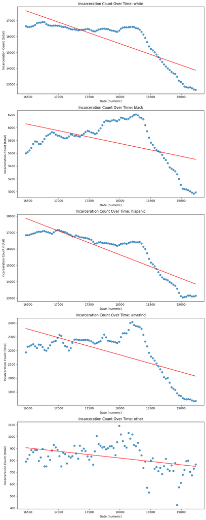

```python
races = merged_df['race'].unique()
fig, axes = plt.subplots(len(races), 1, figsize=(10, 5 * len(races)))

for i, race in enumerate(races):
    df_race = merged_df[merged_df['race'] == race]
    plot_scatter_with_regression(axes[i], df_race['date_numeric'], df_race['total'], f'Incarceration Count Over Time: {race}')

plt.tight_layout()
plt.show()
```

It is interesting that all of the graphs have a negative slope, indicating that the number of incarcerations from across the board have all been dropping. Next, we'll plot the admissions and releases over time by race.

First we will create a color map for all the races so we will know which race is which on the scatter plots.

```python
color_map = {'white': 'blue', 'black' : 'red', 'hispanic' : 'green', 'amerind' : 'yellow', 'other': 'orange'}  # Add more colors as needed
```

Next we will create plots for both admissions and releases

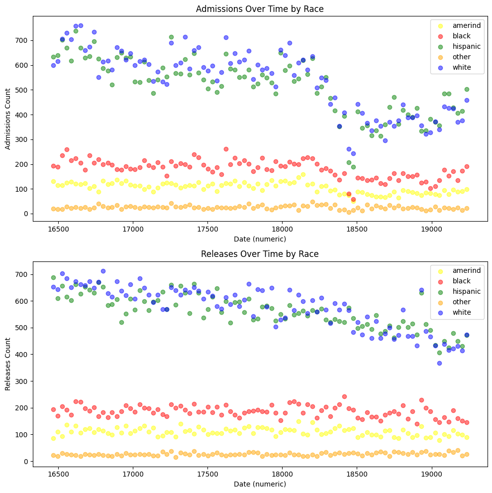

```python
fig, axes = plt.subplots(2, 1, figsize=(10, 10))

for race, group in merged_df[merged_df['metric'] == 'admissions'].groupby('race'):
    axes[0].scatter(group['date_numeric'], group['metric_total'], color=color_map[race], label=race, alpha=0.5)

for race, group in merged_df[merged_df['metric'] == 'releases'].groupby('race'):
    axes[1].scatter(group['date_numeric'], group['metric_total'], color=color_map[race], label=race, alpha=0.5)

axes[0].set_title('Admissions Over Time by Race')
axes[0].set_xlabel('Date (numeric)')
axes[0].set_ylabel('Admissions Count')

axes[1].set_title('Releases Over Time by Race')
axes[1].set_xlabel('Date (numeric)')
axes[1].set_ylabel('Releases Count')

axes[0].legend()
axes[1].legend()

plt.tight_layout()
plt.show()
```

As we can see, both admissions and releases have been largely dominated by White and Hispanic people while Black and American Indian people have been both less admitted, and less released by prisons in Arizona at this time.

## Analysis, Hypothesis Testing and Machine Learning

Now that we have collected, cleaned, and explored our data, we move onto the next step, using machine learning to further enhance our analysis by finding correlations between variables and data. We will be developing a complete linear regression model. We will use our independent variables to create a regression model to determine the correlation between race and incarceration.

To start, we will one-hot encode the race column, or converting the column from categorical data into numerical data.

```python
encoded_df = pd.get_dummies(merged_df, columns=['race'])
```

Next we split the data into features x(race) and y(total).

```python
x = encoded_df.drop(['total', 'metric_total', 'metric', 'date', 'date_numeric'], axis=1)
y = encoded_df['total']
```

Now we split the data into training and testing sets.

```python
x_train, x_test, y_train, y_test = train_test_split(x, y, test_size=0.2, random_state=42)
```

We can now apply our linear regression model to our sets

```python
# Create and train the linear regression model
model = LinearRegression()
model.fit(x_train, y_train)
```

```
LinearRegression()
```

Now that the model has been trained, we evaluate the model's r2 score.

```python
# Evaluate the model's performance
train_score = model.score(x_train, y_train)
test_score = model.score(x_test, y_test)

print("Training r2 Score:", train_score)
print("Testing r2 Score:", test_score)
```

```
Training r2 Score: 0.9824331210280529
Testing r2 Score: 0.9857872658604749
```

OH WOW! The r2 score measures the goodness of fit of a model. It measures the strength of the relationship between the dependent and independent variables by measuring the amount of variance in the dependent variable captured by the model. This means there is a strong correlation between race, and total incarcerations.

# Insight and Policy Decision

We're at the end of our journey! Here we take all of our analysis and observations from the previous steps and draw our conclusions from them! There a a couple things to note from our journey down.

1. There is an overall negative trajectory towards incarcerations over all races.
2. Incarcerations, admissions, and releases are all dominated by White and Hispanic people overall.
3. Our linear regression model demonstrates a strong correlation between race and total incarcerations.

This topic however is one that definitely needs more work. The issue of incarceration and race are both fundamentally American issues that are worthy of intense and dedicated study. Our dataset is very very small, not enough to fully understand the nuance and complexity of the issue. This is intended to be used as a tutorial for beginners to follow along to help understand the Data Science Lifecycle. Down below will be links to additional resources, including the paper for which this dataset was included in, for those interested in this topic.

I hope you enjoyed this tutorial and have a better understanding of how to use and manipulate data!

Relevant links:

Dataset: https://github.com/jkbren/incarcerated-populations-data/tree/main

Paper: https://www.nature.com/articles/s41586-023-05980-2

Relevant Articles:

https://www.prisonpolicy.org/blog/2022/05/19/updated_charts/

https://www.sentencingproject.org/reports/one-in-five-ending-racial-inequity-in-incarceration/

https://www.pewtrusts.org/en/research-and-analysis/issue-briefs/2023/05/racial-disparities-persist-in-many-us-jails

https://www.sentencingproject.org/publications/one-in-five-racial-disparity-in-imprisonment-causes-and-remedies/